# Flow Duration Curve

Worked Example 5.1

# Loading the Data

In this example we are going to use river flow data from the river Ngaruroro which is part of the `international` dataset in the package **hydroDrought**. This dataset becomes accessible by loading the **hydroDrought** package.

```r
library(tidyverse)
library(hydroDrought)
ngaruroro <- intl %>%
  filter(river == "Ngaruroro") %>%
  select(data) %>%
  unnest(data) %>%
  print()
```

```
## # A tibble: 20,473 x 2
##    time       discharge
##    <date>         <dbl>
##  1 1963-09-20      30.5
##  2 1963-09-21      52.8
##  3 1963-09-22      43.6
##  4 1963-09-23      37.3
##  5 1963-09-24      32.3
##  6 1963-09-25      29.0
##  7 1963-09-26      25.3
##  8 1963-09-27      22.4
##  9 1963-09-28      19.9
## 10 1963-09-29      18.2
## # … with 20,463 more rows
```

All years of daily data from River Ngaruroro at Kuripapango (NZ) are used here to construct a flow duration curve based on a daily time step, $\Delta t = 1$ day. The total number of $\Delta t$ intervals is then $N = 20473$ days. Table 5.1 lists the first seven flow values. The first two columns show the date and the corresponding riverflow value, $Q$.

# Calculation of the FDC

The flow duration curve is constructed following the calculation steps as given in the right part of the table:

- The rank, $i$, of each value is calculated (using the `rank()` function), which means that if the list is sorted, the rank will be its position. Here the series is sorted in descending order and the $i^{th}$ largest value has rank $i$ (i.e. the largest value has rank 1).
- The exceedance frequency, $EF_{Q_i}$ is calculated as:
  $$EF_{Q_i} = \frac{i} {N}$$
  which gives an estimate of the empirical exceedance frequency of the $i^{th}$ largest event. $EF_{Q_i}$ designates here the observed frequency when the flow, $Q$, is larger than the flow value with rank $i$, $Q_i$ .

```r
exceedance_frequency <- function(flow)
{
  # current rank
  i <- rank(-flow, ties.method = "min", na.last = "keep")

  # largest rank in sample (= number of non-missing values)
  N <- length(na.omit(flow))

  # the exceedance frequency can be seen as the relative rank
  return(i / N)
}

ngaruroro <- ngaruroro %>%
  mutate(
    rank = rank(-discharge, ties.method = "min"),
    freq.exc = exceedance_frequency(discharge)
  )
```

Table 5.1 Calculation of a daily flow duration curve for River Ngaruroro at Kuripapango, NZ

| Date | $Q$ in $m^3s^{-1}$ Flow | $i$ Rank | $EF_Q$ Exceedance Frequency |
| --- | --- | --- | --- |
| 1963-09-20 | 30.519 | 2501 | 0.124 |
| 1963-09-21 | 52.766 | 827 | 0.041 |
| 1963-09-22 | 43.633 | 1228 | 0.061 |
| 1963-09-23 | 37.258 | 1686 | 0.083 |
| 1963-09-24 | 32.322 | 2240 | 0.111 |
| 1963-09-25 | 28.977 | 2736 | 0.135 |
| 1963-09-26 | 25.315 | 3482 | 0.172 |

# Tabulation of the FDC

- Corresponding values of riverflow ($Q$ in m<sup>3</sup>s<sup>-1</sup>) and exceedance frequency ($EF_{Q_i}$ in %) are tabulated.

  Tobias: Tabulation was done implicitly in the sections before.
- The two columns are sorted by $EF_{Q_i}$.

  Tobias: Sorting is not required. I suggest to delete the section “Tabulation of the FDC” entirely.

# Plot of the FDC

The sorted table columns are then plotted (Figure 5.2). The ordinate axis is here logarithmic.

Figure 5.2 Flow duration curve for River Ngaruroro at Kuripapango, NZ.

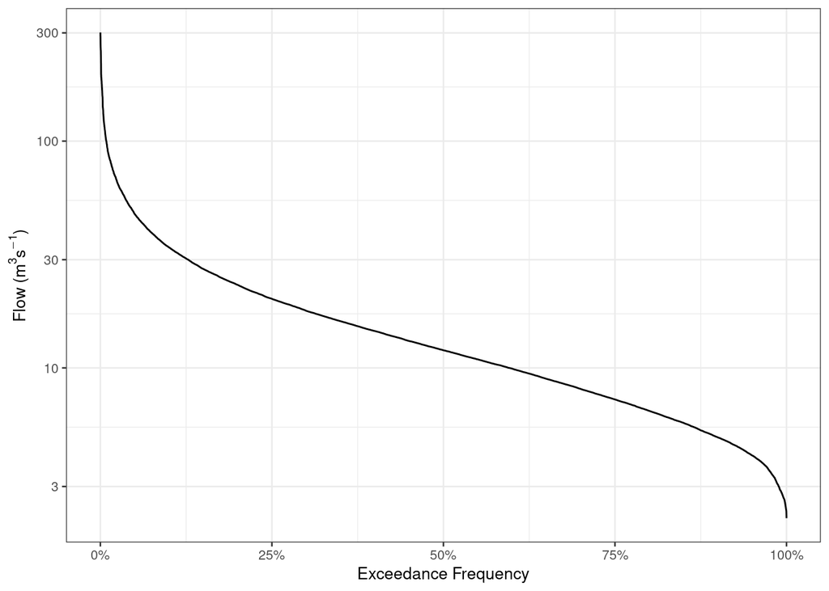

```r
library(scales)
ggplot(ngaruroro, aes(x = freq.exc, y = discharge)) +
  geom_line() +
  scale_y_log10() +
  scale_x_continuous(labels = percent_format(accuracy = 1)) +
  labs(x = "Exceedance Frequency",
       y = expression(paste("Flow (", m^{3}, s^{-1}, ")")))
```

# Selected exceedance values

Values for a particular frequency, for example the 90-percentile ($Q_{90}$), can be obtained as the value of $Q$ corresponding to the largest value of $EF_{Q_i}$ that is less than or equal to the value of $EF_{Q_i}$ sought for. A sample of corresponding values in this range is shown in Table 5.2, and the 90-percentile flow value is taken as 4.936 m<sup>3</sup>s<sup>-1</sup>. Alternatively, in case of large differences between successive values, a linear interpolation can be used.

Table 5.2 An extract of values corresponding to $Q_{90}$.

| Date | $Q$ in ${m^3s^{-1}}$ Flow | $i$ Rank | $EF_Q$ Exceedance Frequency |
| --- | --- | --- | --- |
| 2001-03-03 | 4.938 | 18202 | 0.89993 |
| 1999-01-16 | 4.936 | 18203 | 0.89998 |
| 2005-11-24 | 4.936 | 18203 | 0.89998 |
| 2013-01-18 | 4.936 | 18203 | 0.89998 |
| 1990-12-29 | 4.935 | 18206 | 0.90013 |
| 1968-02-17 | 4.933 | 18207 | 0.90018 |
| 1994-03-28 | 4.933 | 18207 | 0.90018 |
| 1998-03-29 | 4.933 | 18207 | 0.90018 |
| 2002-03-26 | 4.933 | 18207 | 0.90018 |

# Fast-Track

The function `lfquantile()` calculates low-flow/riverflow quantiles directly. The exact (interpolated) values for $Q_{95}$, $Q_{90}$ and $Q_{80}$ would be:

```r
lfquantile(ngaruroro$discharge, exc.freq = c(0.95, 0.9, 0.8))
```

```
##     Q95     Q90     Q80
## 4.10925 4.93600 6.46200
```

# Standardized Flow Duration Curves

Comparing FDCs from different catchments requires standardization eg. dividing the discharges by the catchment area, the median or the mean discharge.

```r
lambournRay <- intl %>%
  filter(river %in% c("Lambourn", "Ray")) %>%
  select(river, area = catchment, data)

lambournRay <- lambournRay %>%
  mutate(
    data = map2(data, area, ~mutate(.x, rel.discharge = discharge * 1000 / .y))
  ) %>%
  print()
```

```
## # A tibble: 2 x 3
##   river     area data
##   <fct>    <dbl> <list>
## 1 Ray         19 <tibble [20,454 × 3]>
## 2 Lambourn   234 <tibble [20,973 × 3]>
```

```r
fdc <- lambournRay %>%
  select(river, data) %>%
  unnest(cols = data) %>%
  group_by(river) %>%
  mutate(freq.exc = exceedance_frequency(rel.discharge)) %>%
  print()
```

```
## # A tibble: 41,427 x 5
## # Groups:   river [2]
##    river time       discharge rel.discharge freq.exc
##    <fct> <date>         <dbl>         <dbl>    <dbl>
##  1 Ray   1962-10-01     0.082         4.32     0.216
##  2 Ray   1962-10-02     0.059         3.11     0.261
##  3 Ray   1962-10-03     0.025         1.32     0.396
##  4 Ray   1962-10-04     0.014         0.737    0.486
##  5 Ray   1962-10-05     0.008         0.421    0.553
##  6 Ray   1962-10-06     0.006         0.316    0.584
##  7 Ray   1962-10-07     0.006         0.316    0.584
##  8 Ray   1962-10-08     0.006         0.316    0.584
##  9 Ray   1962-10-09     0.003         0.158    0.664
## 10 Ray   1962-10-10     0.003         0.158    0.664
## # … with 41,417 more rows
```

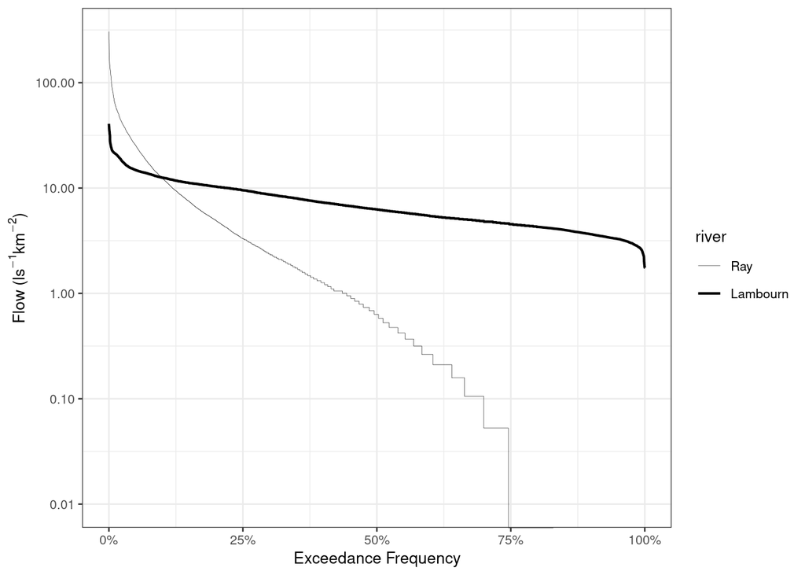

```r
ggplot(fdc, mapping = aes(x = freq.exc, y = rel.discharge,
                          size = river)) +
  geom_step(direction = "vh") +
  scale_size_manual(values = c(0.1, 0.75)) +
  scale_y_log10(limits = c(0.01, NA),
                labels = number_format(accuracy = 0.01)) +
  scale_x_continuous(labels = percent_format(accuracy = 1)) +
  labs(x = "Exceedance Frequency",
       y = expression(paste("Flow (", l, s^{-1}, km^{-2}, ")")))
```